# INTRO TESI COMPONENTI DECOMPOSTE

Carnati Emanuele, 781231

## CARICAMENTO DELLE LIBRERIE

```r
list.of.packages <- c("xts", "forecast", "tseries", "ggplot2", "urca", "tsoutliers", "fpp2", "timeSeries", "KFAS", "tidyverse", "glue", "forcats", "timetk", "tidyquant", "tibbletime", "cowplot", "recipes", "rsample", "yardstick", "keras", "dplyr")
new.packages <- list.of.packages[!(list.of.packages %in% installed.packages()[,"Package"])]
if(length(new.packages)) install.packages(new.packages)

library(xts)
library(forecast)
library(tseries)
library(ggplot2)
library(urca)
library(tsoutliers)
library(fpp2)
library(timeSeries)
library(KFAS)
library(tidyverse)
library(glue)
library(forcats)
library(timetk)
library(tidyquant)
library(tibbletime)
library(cowplot)
library(recipes)
library(rsample)
library(yardstick)
library(keras)
library(forecast)
library(dplyr)
```

## VISUALIZZAZIONE E CONSIDERAZIONI SUL DATASET

*Caricamento ed analisi preliminare* Definire i percorsi

```r
folder_dati = paste(dirname(dirname(rstudioapi::getSourceEditorContext()$path)), "/dati", sep = "")
folder_codice = dirname(rstudioapi::getSourceEditorContext()$path)
folder_risultati = paste(dirname(dirname(rstudioapi::getSourceEditorContext()$path)), "/risultati", sep = "")
```

*Caricamento dati con sunday*

```r
# caricamento del dataset
load <- read.csv(paste(folder_risultati, "/df_grouped_date.csv", sep=""), sep = ",", na.strings =c("",NA), stringsAsFactors = FALSE)
load[is.na(load)] <- 0

load$Minuti.NO.ciclo <- as.numeric(gsub(",", ".", gsub("\\.", "", load$Minuti.NO.ciclo)))
load$Minuti.ciclo <- as.numeric(gsub(",", ".", gsub("\\.", "", load$Minuti.ciclo)))
load$Efficienza <- as.numeric(gsub(",", ".", gsub("\\.", "", load$Efficienza)))
```

Creo due variabili aggiuntive, giorno e giorno mese (formato “ggmm”), che utilizzero’ poi per analizzare il dataset

```r
load$Date <- strptime(load$Date, format = '%Y-%m-%d')

load$giorno <- as.factor(strftime(load$Date, format = '%A'))

load$giorno_mese <- as.factor(strftime(load$Date, format = '%m%d'))

head(load)
```

|  | Date | Minuti.ciclo | Minuti.NO.ciclo | Efficienza | giorno | giorno_mese |
| --- | --- | --- | --- | --- | --- | --- |
| 1 |  | 0 | 0 | 0 | Martedì | 0101 |
| 2 |  | 0 | 0 | 0 | Mercoledì | 0102 |
| 3 |  | 0 | 0 | 0 | Giovedì | 0103 |
| 4 |  | 0 | 0 | 0 | Venerdì | 0104 |
| 5 |  | 0 | 0 | 0 | Sabato | 0105 |
| 6 |  | 0 | 0 | 0 | Domenica | 0106 |

Prima visualizzazione dei dati, visualizzo in formato xts

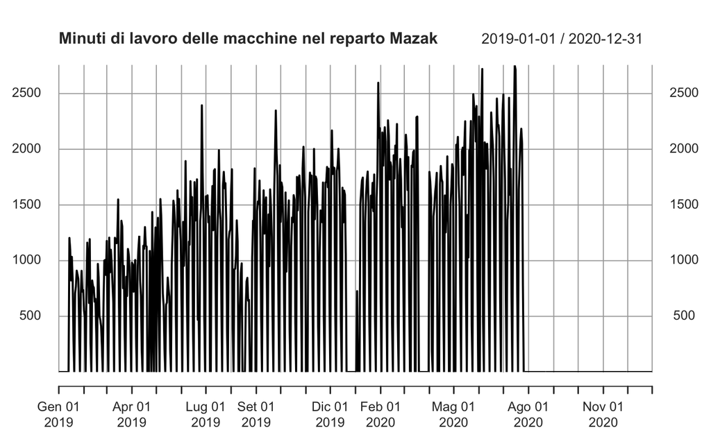

```r
plot(xts(load$Minuti.ciclo, load$Date, frequency = 7), main = 'Minuti di lavoro delle macchine nel reparto Mazak')
```

C’è una dipendenza stagionale che si evince dal grafico. Inoltre ci sono altre componenti come trend crescente. Durante i weekend il valore diminuisce notevolmente, con la domenica che si azzera, quindi le domeniche vengono eliminate.

*Caricamento dati no sunday*

```r
# caricamento del dataset
load <- read.csv(paste(folder_risultati, "/df_min_ciclo_nosunday_no0.csv", sep=""), sep = ",", na.strings =c("",NA), stringsAsFactors = FALSE)
load[is.na(load)] <- 0

#load$Minuti.NO.ciclo <- as.numeric(gsub(",", ".", gsub("\\.", "", load$Minuti.NO.ciclo)))
load$Minuti.ciclo <- as.numeric(gsub(",", ".", gsub("\\.", "", load$Minuti.ciclo)))
#load$Efficienza <- as.numeric(gsub(",", ".", gsub("\\.", "", load$Efficienza)))
```

Creo due variabili aggiuntive, giorno e giorno mese (formato “ggmm”), che utilizzero’ poi per analizzare il dataset

```r
load$Date <- strptime(load$Date, format = '%Y-%m-%d')

load$giorno <- as.factor(strftime(load$Date, format = '%A'))

load$giorno_mese <- as.factor(strftime(load$Date, format = '%m%d'))

head(load)
```

|  | Date | Minuti.ciclo | giorno | giorno_mese |
| --- | --- | --- | --- | --- |
| 1 |  | 1199.103 | Martedì | 0101 |
| 2 |  | 1199.103 | Mercoledì | 0102 |
| 3 |  | 1199.103 | Giovedì | 0103 |
| 4 |  | 1199.103 | Venerdì | 0104 |
| 5 |  | 1199.103 | Sabato | 0105 |
| 6 |  | 1199.103 | Lunedì | 0107 |

Prima visualizzazione dei dati, visualizzo in formato xts

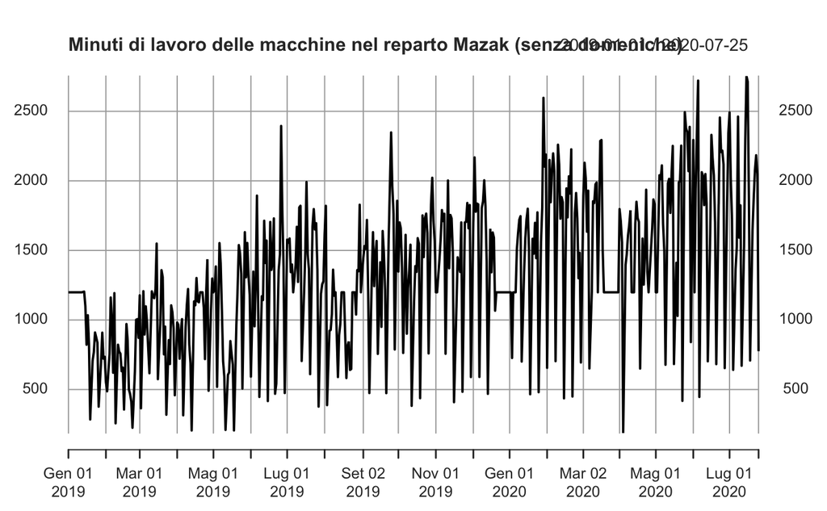

```r
plot(xts(load$Minuti.ciclo, load$Date, frequency = 6), main = 'Minuti di lavoro delle macchine nel reparto Mazak (senza domeniche)')
```

Tuttavia bisogna intercettare anche i valori nulli e sostituirli con la media eh!!!

```r
load2<- load[1:491,]

load2$Minuti.ciclo <- replace(load2$Minuti.ciclo, load2$Minuti.ciclo==0,mean(load2$Minuti.ciclo, na.rm = T))
load <- load2
```

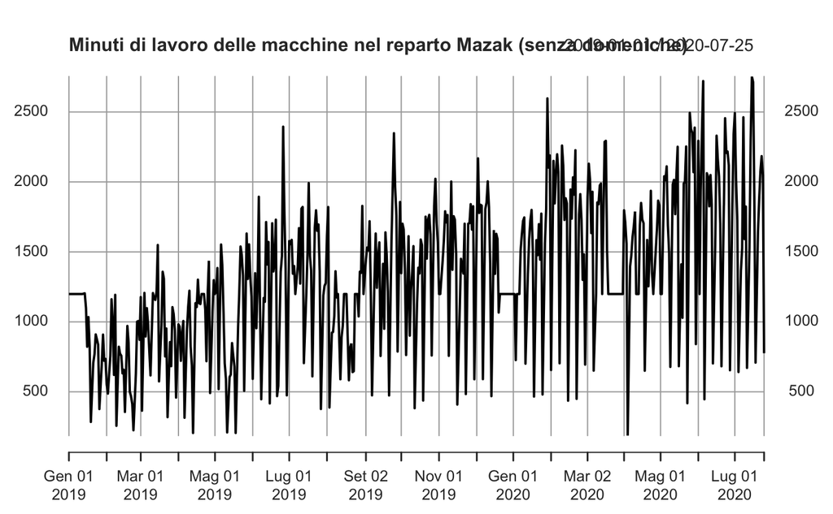

```r
plot(xts(load$Minuti.ciclo, load$Date, frequency = 6), main = 'Minuti di lavoro delle macchine nel reparto Mazak (senza domeniche)')
```

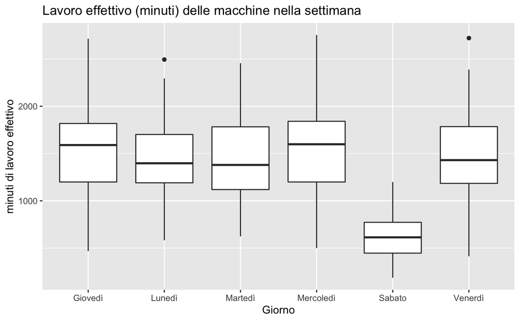

```r
# Demand by day of the week
ggplot(load[1:491,], aes(giorno, Minuti.ciclo)) + geom_boxplot() + xlab('Giorno') + ylab('minuti di lavoro effettivo') + ggtitle('Lavoro effettivo (minuti) delle macchine nella settimana')
```

```r
ts <- msts(load$Minuti.ciclo, c(6,313)) # multiseasonal ts
ts_train <- msts(ts[1:313], c(6,313))
ts_test <- msts(ts[314:491], c(6,313))
```

```r
ts <- ts(load$Minuti.ciclo, frequency = 6)
```

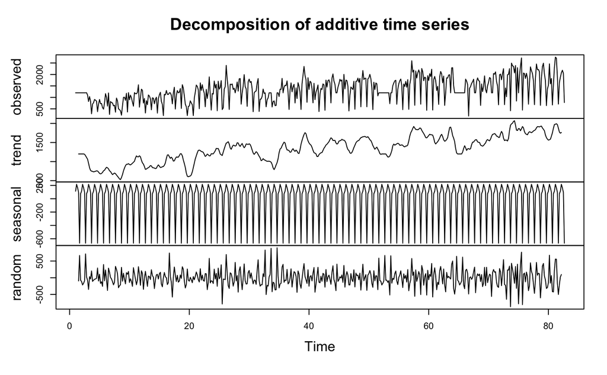

```r
plot(decompose(ts))
```

Le componenti decomposte ci mostrano un trend crescente ed una stagionalità settimanale.

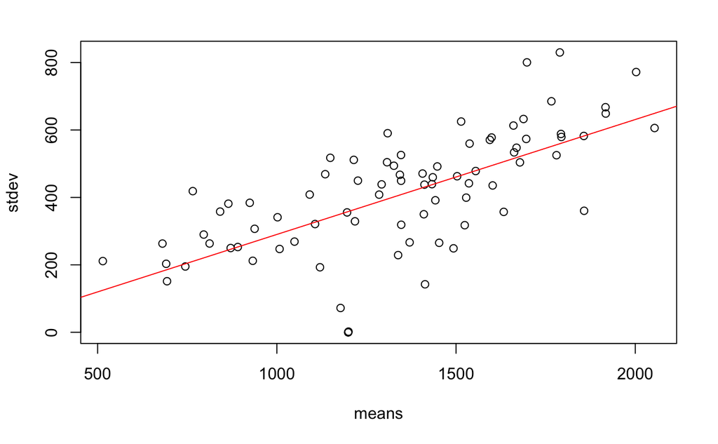

```r
serie = ts(load$Minuti.ciclo, frequency = 6)
means <- tapply(serie, floor(time(serie)), mean)
stdev <- tapply(serie, floor(time(serie)), sd)

plot(means, stdev)
abline(lm(stdev ~ means), col ='red')
```

vediamo che è abbastanza lineare per cui prendiamo la trasformazione logaritmica per correggere la non stazionarietà in varianza